# Latihan Pertemuan 4

Ignacia Manuela Bregina | G1401211072

2023-09-16

## SOAL NOMOR 1 | MA(2)

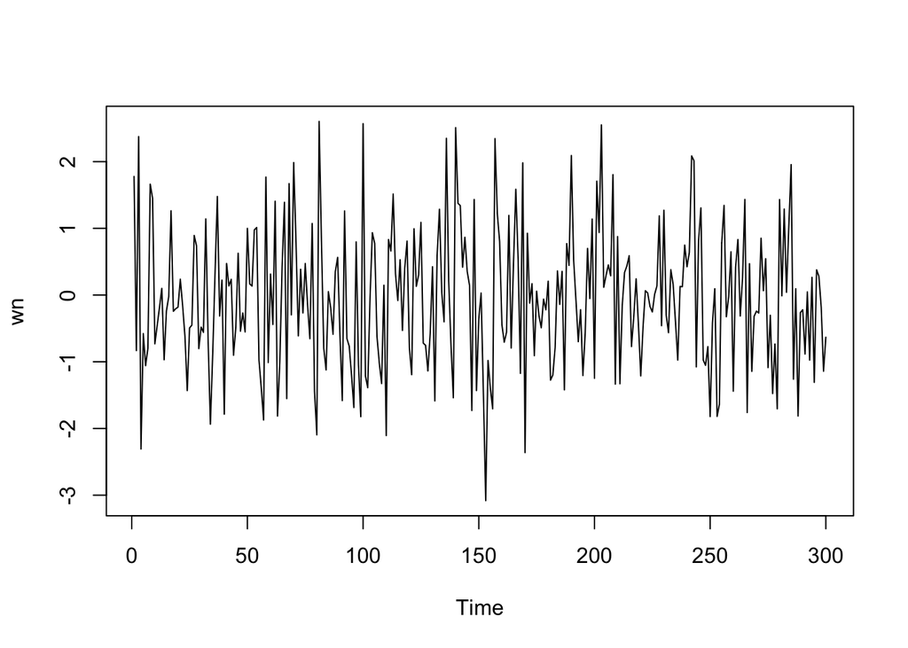

```r
wn <- rnorm(300)
ts.plot(wn)
```

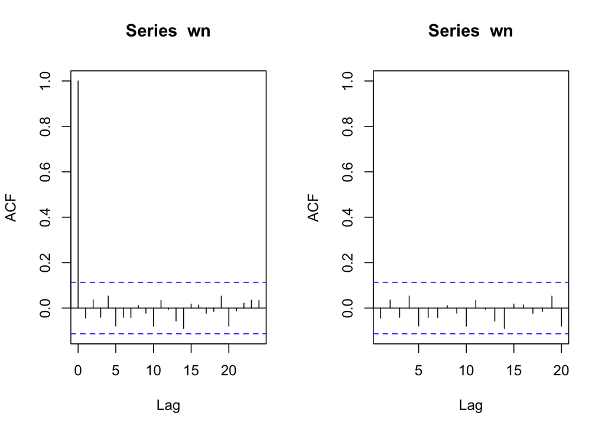

```r
par(mfrow = c(1, 2))
acf(wn)
acf(wn, xlim = c(1, 20))
```

Bentuk loop dapat dilihat dari rumus MA(2) yang hendak dibangkitkan:

$$y_t = e_t+0.4e_{t-1}+0.6e_{t-2}$$

# Pembangkitan Proses MA(2)

```r
set.seed(1072)
ma <- wn[1]
ma[2] <- wn[2]
```

```r
for(i in 3:300){
   ma[i] <- wn[i] + 0.4 * wn[i - 1] + 0.6 * wn[i - 2]
}
ma
```

```
##   [1]  1.778285291 -0.832807593  3.109815095 -1.857177587 -0.075272556
##   [6] -2.674132425 -1.567071624  0.708553260  1.640265011  0.847231285
##  [11]  0.120360298 -0.807523339 -0.249502521 -1.040469936 -0.566888972
##  [16] -0.700292788  1.110934748  0.248597022  0.456141416 -0.409901261
##  [21]  0.042696044 -0.171551546 -0.536444600 -1.773194422 -1.435635099
##  [26] -1.507411686  0.417613382  0.826168413  0.028785812 -0.358449621
##  [31] -1.234592540  0.629032502 -0.541976745 -1.515763108 -2.062118391
##  [36] -1.208659625  1.067180360  0.462484492  0.984892996 -1.884690729
##  [41] -0.106930513 -0.745445199  0.574349852 -0.726289644 -0.699264624
##  [46] -0.106638540 -0.578610385 -0.108885798 -0.985164164  0.617625317
##  [51]  0.235114573  0.801449657  1.130345335  1.484148969  0.015000108
##  [56] -1.178155636 -3.017056564  0.182519379 -1.427507752  0.971233271
##  [61] -0.921771837  1.418949992 -1.515974482 -0.897172536 -1.066573665
##  [66]  0.952886271 -0.739460220  1.883617905 -0.560540104  2.869777721
##  [71]  1.414378873  0.898899072  0.620295052 -0.481407548  0.597490346
```

[output cut: 45 more lines]

```r
ma2 <- arima.sim(list(order=c(0,0,1), ma=0.4, 0.6), n=300)
ma2
```

```
## Time Series:
## Start = 1
## End = 300
## Frequency = 1
##   [1] -2.917183123 -1.488761047 -0.150083747 -1.805808787  0.285713040
##   [6] -0.540206861 -2.438367779  0.395027226 -0.835416279 -0.058451172
##  [11] -0.863977000 -1.132232702  1.339231636  0.597266074  1.338456383
##  [16]  0.929597526  0.829857558  0.248349573 -0.259751769  1.030441336
##  [21]  0.675364136 -1.212863459  0.163533690 -1.334255919 -1.492135601
##  [26]  0.294003733  0.530537669  1.887358526  1.210226903  1.404685599
##  [31]  3.126218753  0.413243374  0.677064547  0.934654353 -0.117080379
##  [36] -0.322134004 -1.148446855 -1.390053761  0.326868976 -1.212498572
##  [41] -1.290288023  0.108665309 -1.421214397 -0.909291825 -0.304781312
##  [46]  0.080760122  0.041443760  1.000741839 -1.374435614 -2.936640534
##  [51] -1.653946589 -1.618326702 -0.068889653  1.909673477  1.136517166
```

[output cut: 49 more lines]

# Karakteristik MA(2)

# Plot Time Series

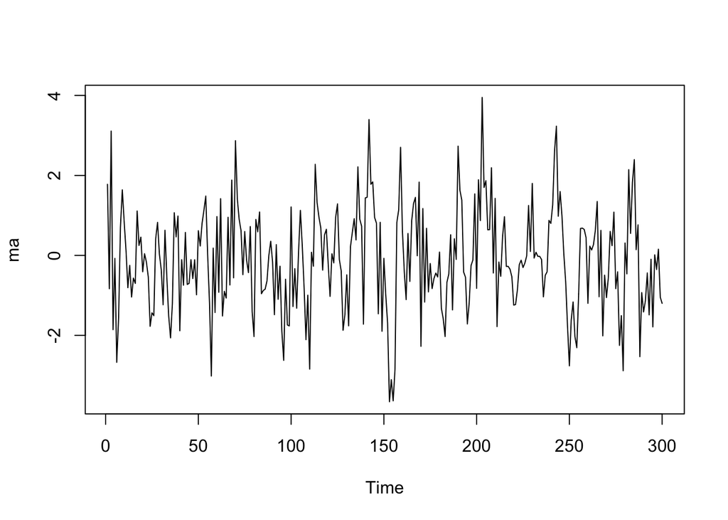

```r
ts.plot(ma)
```

Berdasarkan plot time series diatas terlihat bahwa data MA(2) yang dibangkitkan stasioner dalam rataan

# Plot ACF

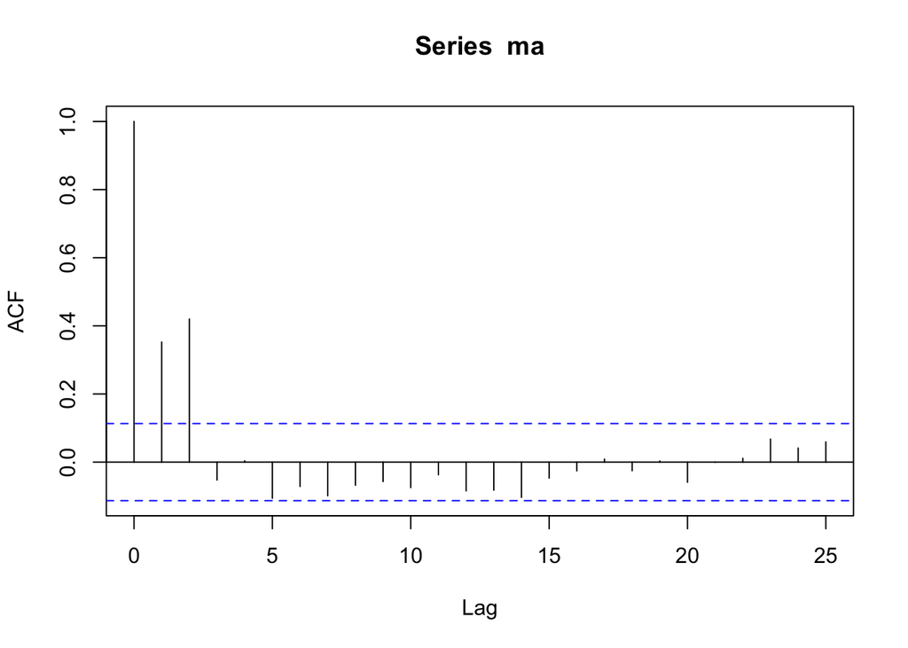

```r
acf(ma,lag.max = 25)
```

# Plot PACF

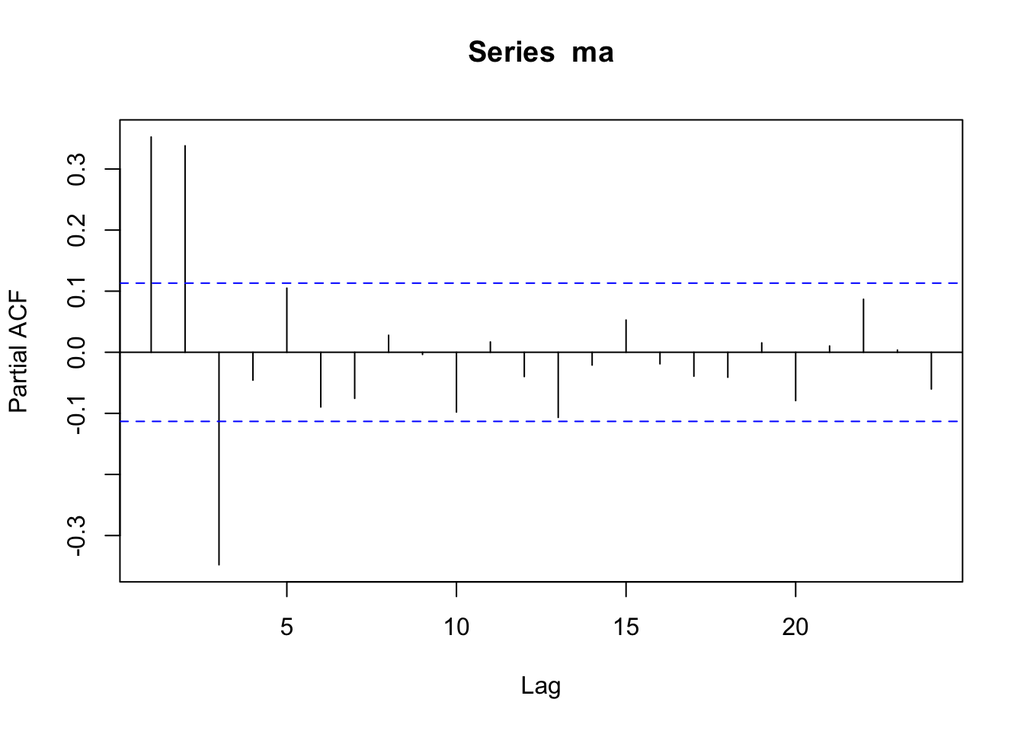

```r
pacf(ma)
```

# Plot EACF

```r
TSA::eacf(ma)
```

```
## AR/MA
##   0 1 2 3 4 5 6 7 8 9 10 11 12 13
## 0 x x o o o o o o o o o  o  o  o
## 1 x x o o o o o o o o o  o  o  o
## 2 x x o x o o o o o o o  o  o  o
## 3 o x x o o o o o o o o  o  o  o
## 4 x o x x o o o o o o o  o  o  o
## 5 x x x o x o x o o o o  o  o  o
## 6 x x x o x o o o o o o  o  o  o
## 7 x o x x o o o o x o o  o  o  o
```

# Korelasi antara $Y_t$ dengan $Y_{t-1}$

```r
#Yt dengan Yt-1
#Yt
yt_ma <- ma2[-1]
yt_ma
```

```
##   [1] -1.488761047 -0.150083747 -1.805808787  0.285713040 -0.540206861
##   [6] -2.438367779  0.395027226 -0.835416279 -0.058451172 -0.863977000
##  [11] -1.132232702  1.339231636  0.597266074  1.338456383  0.929597526
##  [16]  0.829857558  0.248349573 -0.259751769  1.030441336  0.675364136
##  [21] -1.212863459  0.163533690 -1.334255919 -1.492135601  0.294003733
##  [26]  0.530537669  1.887358526  1.210226903  1.404685599  3.126218753
##  [31]  0.413243374  0.677064547  0.934654353 -0.117080379 -0.322134004
##  [36] -1.148446855 -1.390053761  0.326868976 -1.212498572 -1.290288023
##  [41]  0.108665309 -1.421214397 -0.909291825 -0.304781312  0.080760122
##  [46]  0.041443760  1.000741839 -1.374435614 -2.936640534 -1.653946589
##  [51] -1.618326702 -0.068889653  1.909673477  1.136517166  0.238597501
##  [56] -0.142973536 -0.962881088 -1.082016634 -0.760103892  0.058908507
##  [61]  0.236079059  0.566861982 -0.131922797  1.703937404  0.834322386
##  [66]  0.363989048  0.939036492  2.026805783  1.049170849 -0.938141887
##  [71] -0.668968835 -0.462710785 -1.849518979 -1.293419291 -0.493823027
```

[output cut: 45 more lines]

```r
#Yt-1
yt_1_ma <- ma[-300]
yt_1_ma
```

```
##   [1]  1.778285291 -0.832807593  3.109815095 -1.857177587 -0.075272556
##   [6] -2.674132425 -1.567071624  0.708553260  1.640265011  0.847231285
##  [11]  0.120360298 -0.807523339 -0.249502521 -1.040469936 -0.566888972
##  [16] -0.700292788  1.110934748  0.248597022  0.456141416 -0.409901261
##  [21]  0.042696044 -0.171551546 -0.536444600 -1.773194422 -1.435635099
##  [26] -1.507411686  0.417613382  0.826168413  0.028785812 -0.358449621
##  [31] -1.234592540  0.629032502 -0.541976745 -1.515763108 -2.062118391
##  [36] -1.208659625  1.067180360  0.462484492  0.984892996 -1.884690729
##  [41] -0.106930513 -0.745445199  0.574349852 -0.726289644 -0.699264624
##  [46] -0.106638540 -0.578610385 -0.108885798 -0.985164164  0.617625317
##  [51]  0.235114573  0.801449657  1.130345335  1.484148969  0.015000108
##  [56] -1.178155636 -3.017056564  0.182519379 -1.427507752  0.971233271
##  [61] -0.921771837  1.418949992 -1.515974482 -0.897172536 -1.066573665
##  [66]  0.952886271 -0.739460220  1.883617905 -0.560540104  2.869777721
##  [71]  1.414378873  0.898899072  0.620295052 -0.481407548  0.597490346
```

[output cut: 45 more lines]

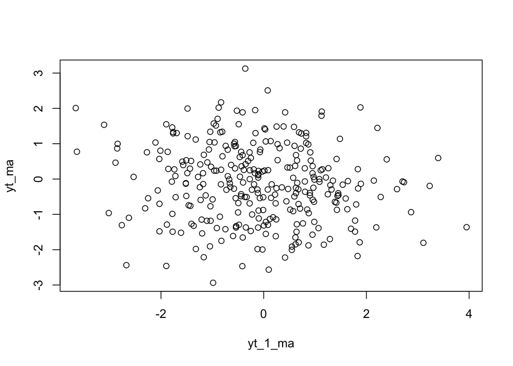

```r
plot(y=yt_ma,x=yt_1_ma)
```

```r
#Yt dengan Yt-2
#Yt
yt_ma2 <- ma2[-c(1,2)]
yt_ma2
```

```
##   [1] -0.150083747 -1.805808787  0.285713040 -0.540206861 -2.438367779
##   [6]  0.395027226 -0.835416279 -0.058451172 -0.863977000 -1.132232702
##  [11]  1.339231636  0.597266074  1.338456383  0.929597526  0.829857558
##  [16]  0.248349573 -0.259751769  1.030441336  0.675364136 -1.212863459
##  [21]  0.163533690 -1.334255919 -1.492135601  0.294003733  0.530537669
##  [26]  1.887358526  1.210226903  1.404685599  3.126218753  0.413243374
##  [31]  0.677064547  0.934654353 -0.117080379 -0.322134004 -1.148446855
##  [36] -1.390053761  0.326868976 -1.212498572 -1.290288023  0.108665309
##  [41] -1.421214397 -0.909291825 -0.304781312  0.080760122  0.041443760
##  [46]  1.000741839 -1.374435614 -2.936640534 -1.653946589 -1.618326702
##  [51] -0.068889653  1.909673477  1.136517166  0.238597501 -0.142973536
##  [56] -0.962881088 -1.082016634 -0.760103892  0.058908507  0.236079059
##  [61]  0.566861982 -0.131922797  1.703937404  0.834322386  0.363989048
##  [66]  0.939036492  2.026805783  1.049170849 -0.938141887 -0.668968835
##  [71] -0.462710785 -1.849518979 -1.293419291 -0.493823027 -0.297922471
```

[output cut: 45 more lines]

```r
#Yt-2
yt_2_ma <- ma2[-c(299,300)]
yt_2_ma
```

```
##   [1] -2.917183123 -1.488761047 -0.150083747 -1.805808787  0.285713040
##   [6] -0.540206861 -2.438367779  0.395027226 -0.835416279 -0.058451172
##  [11] -0.863977000 -1.132232702  1.339231636  0.597266074  1.338456383
##  [16]  0.929597526  0.829857558  0.248349573 -0.259751769  1.030441336
##  [21]  0.675364136 -1.212863459  0.163533690 -1.334255919 -1.492135601
##  [26]  0.294003733  0.530537669  1.887358526  1.210226903  1.404685599
##  [31]  3.126218753  0.413243374  0.677064547  0.934654353 -0.117080379
##  [36] -0.322134004 -1.148446855 -1.390053761  0.326868976 -1.212498572
##  [41] -1.290288023  0.108665309 -1.421214397 -0.909291825 -0.304781312
##  [46]  0.080760122  0.041443760  1.000741839 -1.374435614 -2.936640534
##  [51] -1.653946589 -1.618326702 -0.068889653  1.909673477  1.136517166
##  [56]  0.238597501 -0.142973536 -0.962881088 -1.082016634 -0.760103892
##  [61]  0.058908507  0.236079059  0.566861982 -0.131922797  1.703937404
##  [66]  0.834322386  0.363989048  0.939036492  2.026805783  1.049170849
##  [71] -0.938141887 -0.668968835 -0.462710785 -1.849518979 -1.293419291
```

[output cut: 45 more lines]

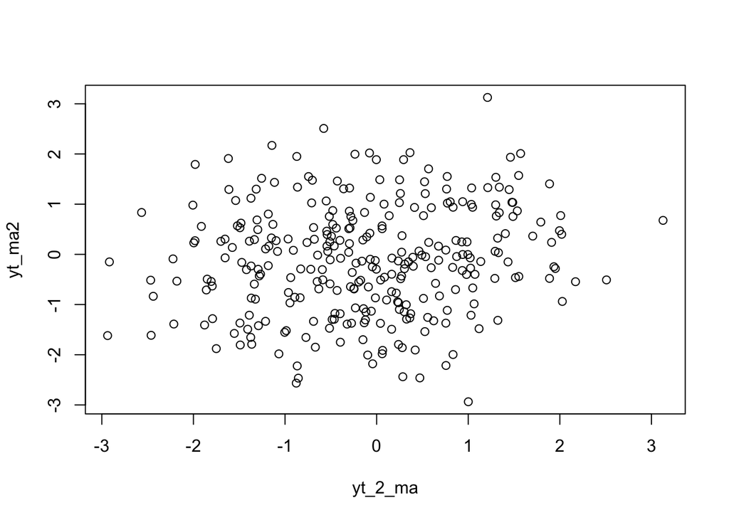

```r
plot(y=yt_ma2,x=yt_2_ma)
```

```r
#Yt dengan Yt-3
#Yt
yt_ma3 <- ma2[-c(1,2,3)]
yt_ma3
```

```
##   [1] -1.805808787  0.285713040 -0.540206861 -2.438367779  0.395027226
##   [6] -0.835416279 -0.058451172 -0.863977000 -1.132232702  1.339231636
##  [11]  0.597266074  1.338456383  0.929597526  0.829857558  0.248349573
##  [16] -0.259751769  1.030441336  0.675364136 -1.212863459  0.163533690
##  [21] -1.334255919 -1.492135601  0.294003733  0.530537669  1.887358526
##  [26]  1.210226903  1.404685599  3.126218753  0.413243374  0.677064547
##  [31]  0.934654353 -0.117080379 -0.322134004 -1.148446855 -1.390053761
##  [36]  0.326868976 -1.212498572 -1.290288023  0.108665309 -1.421214397
##  [41] -0.909291825 -0.304781312  0.080760122  0.041443760  1.000741839
##  [46] -1.374435614 -2.936640534 -1.653946589 -1.618326702 -0.068889653
##  [51]  1.909673477  1.136517166  0.238597501 -0.142973536 -0.962881088
##  [56] -1.082016634 -0.760103892  0.058908507  0.236079059  0.566861982
##  [61] -0.131922797  1.703937404  0.834322386  0.363989048  0.939036492
##  [66]  2.026805783  1.049170849 -0.938141887 -0.668968835 -0.462710785
##  [71] -1.849518979 -1.293419291 -0.493823027 -0.297922471  0.361742196
```

[output cut: 45 more lines]

```r
#Yt-3
yt_3_ma <- ma2[-c(298,299,300)]
yt_3_ma
```

```
##   [1] -2.917183123 -1.488761047 -0.150083747 -1.805808787  0.285713040
##   [6] -0.540206861 -2.438367779  0.395027226 -0.835416279 -0.058451172
##  [11] -0.863977000 -1.132232702  1.339231636  0.597266074  1.338456383
##  [16]  0.929597526  0.829857558  0.248349573 -0.259751769  1.030441336
##  [21]  0.675364136 -1.212863459  0.163533690 -1.334255919 -1.492135601
##  [26]  0.294003733  0.530537669  1.887358526  1.210226903  1.404685599
##  [31]  3.126218753  0.413243374  0.677064547  0.934654353 -0.117080379
##  [36] -0.322134004 -1.148446855 -1.390053761  0.326868976 -1.212498572
##  [41] -1.290288023  0.108665309 -1.421214397 -0.909291825 -0.304781312
##  [46]  0.080760122  0.041443760  1.000741839 -1.374435614 -2.936640534
##  [51] -1.653946589 -1.618326702 -0.068889653  1.909673477  1.136517166
##  [56]  0.238597501 -0.142973536 -0.962881088 -1.082016634 -0.760103892
##  [61]  0.058908507  0.236079059  0.566861982 -0.131922797  1.703937404
##  [66]  0.834322386  0.363989048  0.939036492  2.026805783  1.049170849
##  [71] -0.938141887 -0.668968835 -0.462710785 -1.849518979 -1.293419291
```

[output cut: 45 more lines]

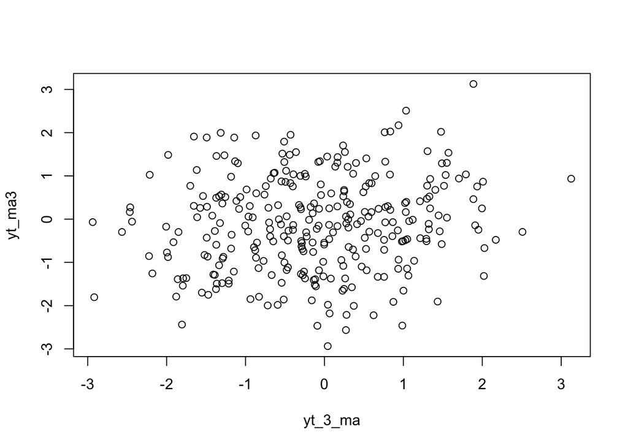

```r
plot(y=yt_ma3,x=yt_3_ma)
```

## SOAL NOMOR 2 | AR(2)

# Proses AR

Proses AR dapat dituliskan sebagai berikut:

$$y_{t} = c + e_t + \phi_{1}Y_{t-1} +
\phi_{2}Y_{t-2} + \dots + \phi_{q}Y_{t-q} = c+{e_t+\sum_{i=1}^p
\phi_iY_{t-i}}$$
Terlihat bahwa $Y_t$ berperan penting dalam pembangkitan proses AR.

# Pembangkitan Proses AR

Akan dicoba membangkitkan proses AR, yaitu AR(2) dengan $\phi_1 = 0.5$ dan $\phi_2 = 0.2$sebanyak 300 observasi dan $c=0$.

# Menyiapkan Data

```r
set.seed(1072)
```

Nilai-nilai selanjutnya dapat dicari melalui *loop*. Bentuk loop dapat dilihat dari rumus AR(2) yang hendak dibangkitkan:

$$Y_t =
e_t+0.5Y_{t-1}+0.2Y_{t-2}$$

```r
n<-length(wn)
n
```

```
## [1] 300
```

```r
ar <- c(1:n)
for (i in 3:n) {
  ar[i] <- wn[i] + 0.5 * ar[i - 1] + 0.2 * ar[i - 2]}
ar
```

```
##   [1]  1.000000000  2.000000000  3.575966958 -0.119896335  0.077544419
##   [6] -1.043531272 -1.303378207  0.802001012  1.593904201  0.225714031
##  [11] -0.027494140 -0.153491841  0.017686959 -0.991364962 -0.731189056
##  [16] -0.586836678  0.823892641  0.051537985 -0.014223938 -0.178972449
##  [21]  0.146095138 -0.120368080 -0.647416839 -1.779823031 -1.512342488
##  [26] -1.563143897 -0.190255283  0.331502755 -0.675488635 -0.752173311
##  [31] -1.071571731  0.455404640 -0.649006429 -2.169202734 -2.104772223
##  [36] -1.177270186  0.468229975 -0.315356246  0.159776039 -1.768986908
##  [41] -0.379432188 -0.406718891 -0.043477500 -1.005756277 -0.991229793
##  [46] -0.069937981 -0.774762910 -0.669732567 -1.042708847  0.344498483
##  [51]  0.130636267  0.269016317  1.136904075  1.635017712  0.069023617
##  [56] -1.033951310 -2.376521199  0.374088621 -1.299413313 -0.260677998
##  [61] -0.830985842  0.939100583 -1.510854492 -1.583134081 -0.665576255
##  [66]  0.741522824 -1.315086176  1.160909656  0.020477620  2.228893544
##  [71]  1.916508031  0.791861821  1.165616489  0.472522014  0.942507705
```

[output cut: 45 more lines]

```r
ar2 <- arima.sim(list(order=c(1,0,0), ar=0.5, 0.2), n=300)
ar2
```

```
## Time Series:
## Start = 1
## End = 300
## Frequency = 1
##   [1] -0.206923156 -1.155733985 -1.289190732  0.979165766  0.437344505
##   [6]  1.578023987  1.174868825  1.262949238  0.609618261  0.053799905
##  [11]  1.157744979  0.801898615 -0.901124601  0.233800953 -1.491100744
##  [16] -1.594485485 -0.163664964  0.195274075  1.874152941  1.436697012
##  [21]  1.923185888  3.605876744  1.158468227  1.514086719  1.317756670
##  [26]  0.317512632 -0.026831407 -1.087627469 -1.504182789 -0.041074797
##  [31] -1.517442610 -1.450247243 -0.339847937 -1.745248640 -1.151786276
##  [36] -0.769009668 -0.226498100 -0.135007983  0.941941421 -1.307243068
##  [41] -2.878976557 -2.203292858 -2.414451299 -0.750993354  1.351683881
##  [46]  1.121486884  0.621082965  0.143432137 -0.824321281 -1.135762334
##  [51] -1.038544382 -0.272098398  0.001160343  0.512558336 -0.080434894
```

[output cut: 49 more lines]

# Karakteristik AR(2)

# Plot Time Series

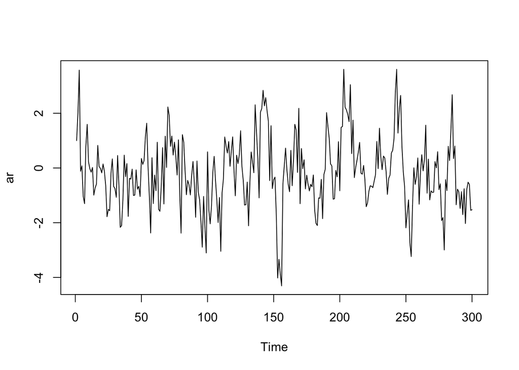

```r
ts.plot(ar)
```

Berdasarkan plot time series tersebut terlihat bahwa data cenderung stasioner pada rataan

# Plot ACF

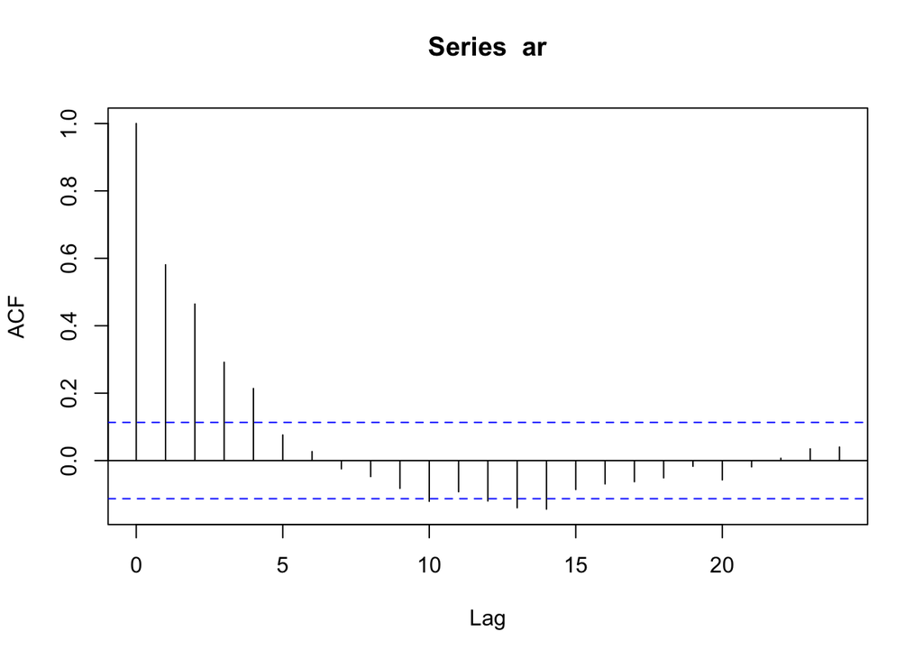

```r
acf(ar)
```

# Plot PACF

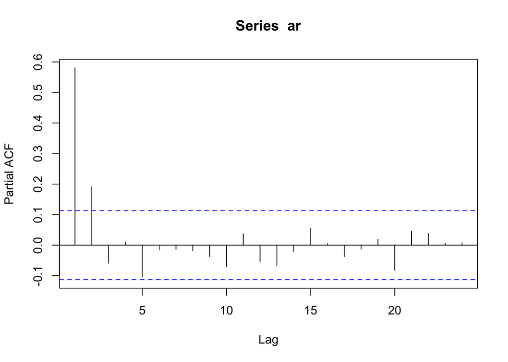

```r
pacf(ar)
```

# Plot EACF

```r
TSA::eacf(ar)
```

```
## AR/MA
##   0 1 2 3 4 5 6 7 8 9 10 11 12 13
## 0 x x x x o o o o o x o  x  x  x
## 1 x x o x o o o o o o o  o  o  o
## 2 x o o x o o o o o o o  o  o  o
## 3 o o x o o o o o o o o  o  o  o
## 4 o x x x o o o o o o o  o  o  o
## 5 x x o x o o o o o o o  o  o  o
## 6 x o o o x o o o o o o  o  o  o
## 7 x o o o x o x o o o o  o  o  o
```

# Korelasi antara $Y_t$ dengan $Y_{t-1}$ , $Y_{t-2}$ , dan $Y_{t-3}$

```r
## Korelasi antara Yt dengan Yt-1
#Yt
yt_ar <- ar[-1]
yt_ar
```

```
##   [1]  2.000000000  3.575966958 -0.119896335  0.077544419 -1.043531272
##   [6] -1.303378207  0.802001012  1.593904201  0.225714031 -0.027494140
##  [11] -0.153491841  0.017686959 -0.991364962 -0.731189056 -0.586836678
##  [16]  0.823892641  0.051537985 -0.014223938 -0.178972449  0.146095138
##  [21] -0.120368080 -0.647416839 -1.779823031 -1.512342488 -1.563143897
##  [26] -0.190255283  0.331502755 -0.675488635 -0.752173311 -1.071571731
##  [31]  0.455404640 -0.649006429 -2.169202734 -2.104772223 -1.177270186
##  [36]  0.468229975 -0.315356246  0.159776039 -1.768986908 -0.379432188
##  [41] -0.406718891 -0.043477500 -1.005756277 -0.991229793 -0.069937981
##  [46] -0.774762910 -0.669732567 -1.042708847  0.344498483  0.130636267
##  [51]  0.269016317  1.136904075  1.635017712  0.069023617 -1.033951310
##  [56] -2.376521199  0.374088621 -1.299413313 -0.260677998 -0.830985842
##  [61]  0.939100583 -1.510854492 -1.583134081 -0.665576255  0.741522824
##  [66] -1.315086176  1.160909656  0.020477620  2.228893544  1.916508031
##  [71]  0.791861821  1.165616489  0.472522014  0.942507705  0.416752798
```

[output cut: 45 more lines]

```r
#Yt-1
yt_1_ar <- ar[-300]
yt_1_ar
```

```
##   [1]  1.000000000  2.000000000  3.575966958 -0.119896335  0.077544419
##   [6] -1.043531272 -1.303378207  0.802001012  1.593904201  0.225714031
##  [11] -0.027494140 -0.153491841  0.017686959 -0.991364962 -0.731189056
##  [16] -0.586836678  0.823892641  0.051537985 -0.014223938 -0.178972449
##  [21]  0.146095138 -0.120368080 -0.647416839 -1.779823031 -1.512342488
##  [26] -1.563143897 -0.190255283  0.331502755 -0.675488635 -0.752173311
##  [31] -1.071571731  0.455404640 -0.649006429 -2.169202734 -2.104772223
##  [36] -1.177270186  0.468229975 -0.315356246  0.159776039 -1.768986908
##  [41] -0.379432188 -0.406718891 -0.043477500 -1.005756277 -0.991229793
##  [46] -0.069937981 -0.774762910 -0.669732567 -1.042708847  0.344498483
##  [51]  0.130636267  0.269016317  1.136904075  1.635017712  0.069023617
##  [56] -1.033951310 -2.376521199  0.374088621 -1.299413313 -0.260677998
##  [61] -0.830985842  0.939100583 -1.510854492 -1.583134081 -0.665576255
##  [66]  0.741522824 -1.315086176  1.160909656  0.020477620  2.228893544
##  [71]  1.916508031  0.791861821  1.165616489  0.472522014  0.942507705
```

[output cut: 45 more lines]

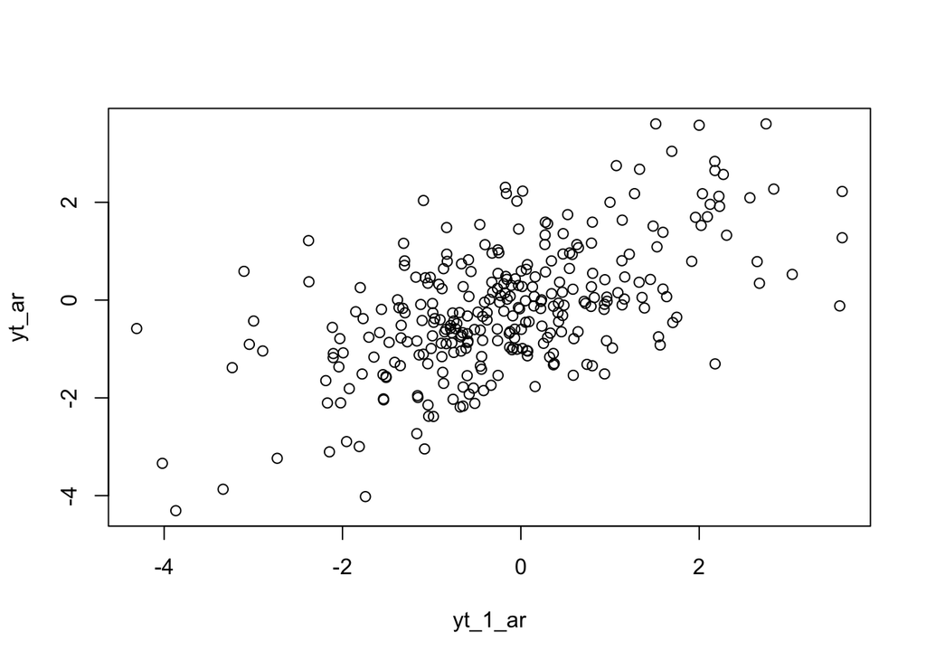

```r
plot(y=yt_ar,x=yt_1_ar)
```

```r
## Korelasi antara Yt dengan Yt-2
#Yt
yt_ar2 <- ar[-c(1,2)]
yt_ar2
```

```
##   [1]  3.575966958 -0.119896335  0.077544419 -1.043531272 -1.303378207
##   [6]  0.802001012  1.593904201  0.225714031 -0.027494140 -0.153491841
##  [11]  0.017686959 -0.991364962 -0.731189056 -0.586836678  0.823892641
##  [16]  0.051537985 -0.014223938 -0.178972449  0.146095138 -0.120368080
##  [21] -0.647416839 -1.779823031 -1.512342488 -1.563143897 -0.190255283
##  [26]  0.331502755 -0.675488635 -0.752173311 -1.071571731  0.455404640
##  [31] -0.649006429 -2.169202734 -2.104772223 -1.177270186  0.468229975
##  [36] -0.315356246  0.159776039 -1.768986908 -0.379432188 -0.406718891
##  [41] -0.043477500 -1.005756277 -0.991229793 -0.069937981 -0.774762910
##  [46] -0.669732567 -1.042708847  0.344498483  0.130636267  0.269016317
##  [51]  1.136904075  1.635017712  0.069023617 -1.033951310 -2.376521199
##  [56]  0.374088621 -1.299413313 -0.260677998 -0.830985842  0.939100583
##  [61] -1.510854492 -1.583134081 -0.665576255  0.741522824 -1.315086176
##  [66]  1.160909656  0.020477620  2.228893544  1.916508031  0.791861821
##  [71]  1.165616489  0.472522014  0.942507705  0.416752798 -0.257699864
```

[output cut: 45 more lines]

```r
#Yt-1
yt_2_ar <- ar[-c(299,300)]
yt_2_ar
```

```
##   [1]  1.000000000  2.000000000  3.575966958 -0.119896335  0.077544419
##   [6] -1.043531272 -1.303378207  0.802001012  1.593904201  0.225714031
##  [11] -0.027494140 -0.153491841  0.017686959 -0.991364962 -0.731189056
##  [16] -0.586836678  0.823892641  0.051537985 -0.014223938 -0.178972449
##  [21]  0.146095138 -0.120368080 -0.647416839 -1.779823031 -1.512342488
##  [26] -1.563143897 -0.190255283  0.331502755 -0.675488635 -0.752173311
##  [31] -1.071571731  0.455404640 -0.649006429 -2.169202734 -2.104772223
##  [36] -1.177270186  0.468229975 -0.315356246  0.159776039 -1.768986908
##  [41] -0.379432188 -0.406718891 -0.043477500 -1.005756277 -0.991229793
##  [46] -0.069937981 -0.774762910 -0.669732567 -1.042708847  0.344498483
##  [51]  0.130636267  0.269016317  1.136904075  1.635017712  0.069023617
##  [56] -1.033951310 -2.376521199  0.374088621 -1.299413313 -0.260677998
##  [61] -0.830985842  0.939100583 -1.510854492 -1.583134081 -0.665576255
##  [66]  0.741522824 -1.315086176  1.160909656  0.020477620  2.228893544
##  [71]  1.916508031  0.791861821  1.165616489  0.472522014  0.942507705
```

[output cut: 45 more lines]

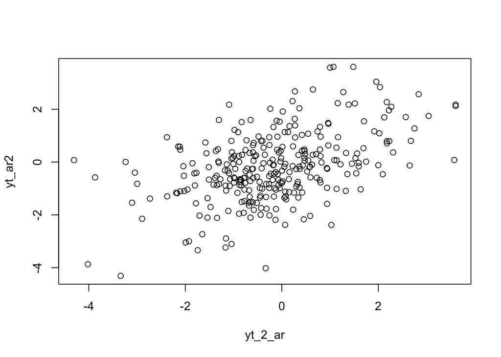

```r
plot(y=yt_ar2,x=yt_2_ar)
```

```r
## Korelasi antara Yt dengan Yt-3
#Yt
yt_ar3 <- ar[-c(1,2,3)]
yt_ar3
```

```
##   [1] -0.119896335  0.077544419 -1.043531272 -1.303378207  0.802001012
##   [6]  1.593904201  0.225714031 -0.027494140 -0.153491841  0.017686959
##  [11] -0.991364962 -0.731189056 -0.586836678  0.823892641  0.051537985
##  [16] -0.014223938 -0.178972449  0.146095138 -0.120368080 -0.647416839
##  [21] -1.779823031 -1.512342488 -1.563143897 -0.190255283  0.331502755
##  [26] -0.675488635 -0.752173311 -1.071571731  0.455404640 -0.649006429
##  [31] -2.169202734 -2.104772223 -1.177270186  0.468229975 -0.315356246
##  [36]  0.159776039 -1.768986908 -0.379432188 -0.406718891 -0.043477500
##  [41] -1.005756277 -0.991229793 -0.069937981 -0.774762910 -0.669732567
##  [46] -1.042708847  0.344498483  0.130636267  0.269016317  1.136904075
##  [51]  1.635017712  0.069023617 -1.033951310 -2.376521199  0.374088621
##  [56] -1.299413313 -0.260677998 -0.830985842  0.939100583 -1.510854492
##  [61] -1.583134081 -0.665576255  0.741522824 -1.315086176  1.160909656
##  [66]  0.020477620  2.228893544  1.916508031  0.791861821  1.165616489
##  [71]  0.472522014  0.942507705  0.416752798 -0.257699864  1.027136723
```

[output cut: 45 more lines]

```r
#Yt-1
yt_3_ar <- ar[-c(298,299,300)]
yt_3_ar
```

```
##   [1]  1.000000000  2.000000000  3.575966958 -0.119896335  0.077544419
##   [6] -1.043531272 -1.303378207  0.802001012  1.593904201  0.225714031
##  [11] -0.027494140 -0.153491841  0.017686959 -0.991364962 -0.731189056
##  [16] -0.586836678  0.823892641  0.051537985 -0.014223938 -0.178972449
##  [21]  0.146095138 -0.120368080 -0.647416839 -1.779823031 -1.512342488
##  [26] -1.563143897 -0.190255283  0.331502755 -0.675488635 -0.752173311
##  [31] -1.071571731  0.455404640 -0.649006429 -2.169202734 -2.104772223
##  [36] -1.177270186  0.468229975 -0.315356246  0.159776039 -1.768986908
##  [41] -0.379432188 -0.406718891 -0.043477500 -1.005756277 -0.991229793
##  [46] -0.069937981 -0.774762910 -0.669732567 -1.042708847  0.344498483
##  [51]  0.130636267  0.269016317  1.136904075  1.635017712  0.069023617
##  [56] -1.033951310 -2.376521199  0.374088621 -1.299413313 -0.260677998
##  [61] -0.830985842  0.939100583 -1.510854492 -1.583134081 -0.665576255
##  [66]  0.741522824 -1.315086176  1.160909656  0.020477620  2.228893544
##  [71]  1.916508031  0.791861821  1.165616489  0.472522014  0.942507705
```

[output cut: 45 more lines]

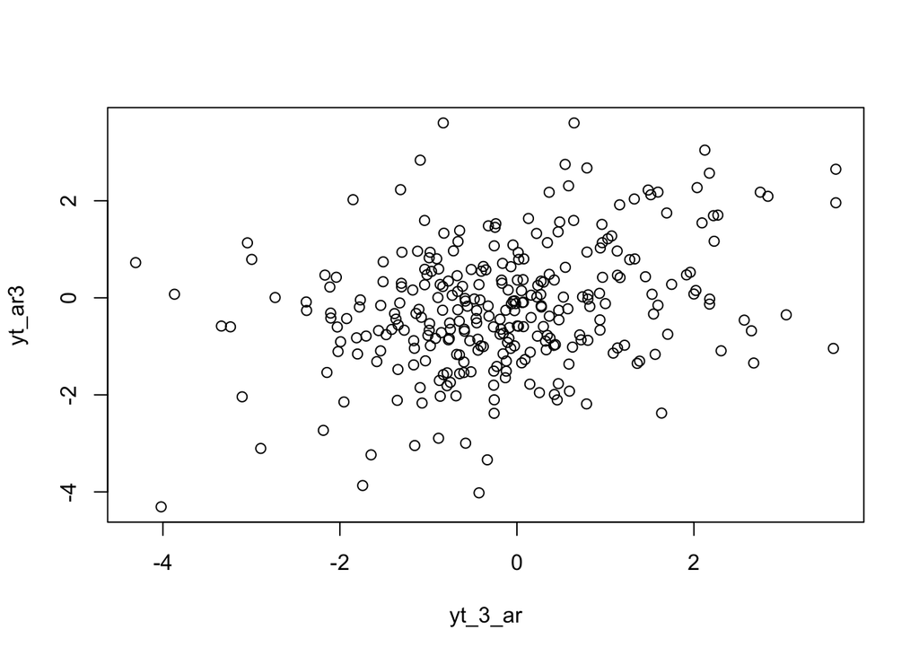

```r
plot(y=yt_ar3,x=yt_3_ar)
```

## SOAL NOMOR 3 | ARMA(2,2)

fungsi umum untuk membangkitkan data ARMA. Input dari fungsi adalah jumlah data yang hendak dibangkitkan, koefisien MA, dan koefisien AR

```r
arma.sim <- function(n, macoef, arcoef){
  manum <- length(macoef)
  arnum <- length(arcoef)
  stopifnot(manum < n & arnum < n)

  wn <- rnorm(n, sd = 0.5)
  init <- max(manum, arnum)

  arma <- wn[1:init]
  for(i in {init+1}:n){
   mastart <- i - manum
   maend <- i-1
   arstart <- i - arnum
   arend <- i-1
   arma[i] <- sum(arcoef * arma[arstart:arend]) + sum(macoef * wn[mastart:maend])  + wn[i]
   }
  return(arma)
}
```

```r
arma22 <- arma.sim(300, c(0.4, 0.6), c(0.5,0.2))

arma22 |> arima(c(2,0,2))
```

```
##
## Call:
## arima(x = arma22, order = c(2, 0, 2))
##
## Coefficients:
##          ar1     ar2     ma1     ma2  intercept
##       0.0555  0.5509  0.7786  0.4464    -0.0297
## s.e.  0.0705  0.0694  0.0716  0.0623     0.1502
##
## sigma^2 estimated as 0.217:  log likelihood = -197.52,  aic = 407.04
```

# Menggunakan rumus manual

$$Y_t = e_t+0.5Y_{t-1}+
0.2Y_{t-2}+0.4e_{t-1}+0.6e_{t-2}$$

```r
phi1 = 0.5
theta1 = 0.4
phi2 = 0.2
theta2 = 0.6
y.arma=c(1:n)
for (i in 5:n){
  y.arma[i] = phi2*y.arma[i-2]+theta2*wn[i-2]+phi1*y.arma[i-1] + theta1*wn[i-1]+wn[i]
}

y.arma
```

```
##   [1]  1.000000e+00  2.000000e+00  3.000000e+00  4.000000e+00  2.524727e+00
##   [6] -6.117687e-01 -1.368010e+00 -9.780572e-02  1.317760e+00  1.486550e+00
##  [11]  1.127187e+00  5.338039e-02  2.625152e-03 -1.028481e+00 -1.080605e+00
##  [16] -1.446291e+00  1.716682e-01  4.517284e-02  5.130615e-01 -1.443360e-01
##  [21]  7.314036e-02 -1.638486e-01 -6.037408e-01 -2.107835e+00 -2.610301e+00
##  [26] -3.234129e+00 -1.721511e+00 -6.814129e-01 -6.562229e-01 -8.228437e-01
##  [31] -1.777259e+00 -4.241657e-01 -1.109511e+00 -2.155352e+00 -3.361697e+00
##  [36] -3.320578e+00 -1.265448e+00 -8.343552e-01  3.146257e-01 -1.894249e+00
##  [41] -9.911298e-01 -1.619860e+00 -4.338061e-01 -1.267165e+00 -1.419608e+00
##  [46] -1.069876e+00 -1.397470e+00 -1.021596e+00 -1.775456e+00 -4.744219e-01
##  [51] -3.571876e-01  5.279715e-01  1.322894e+00  2.251190e+00  1.405174e+00
##  [56] -2.533070e-02 -2.748687e+00 -1.196890e+00 -2.575690e+00 -5.559900e-01
##  [61] -1.714905e+00  4.502996e-01 -1.633806e+00 -1.624015e+00 -2.205343e+00
##  [66] -4.745881e-01 -1.417823e+00  1.079789e+00 -3.042102e-01  2.933630e+00
##  [71]  2.820352e+00  2.895801e+00  2.632266e+00  1.413886e+00  1.830886e+00
```

[output cut: 45 more lines]

#Karakteristik ARMA(2,2)

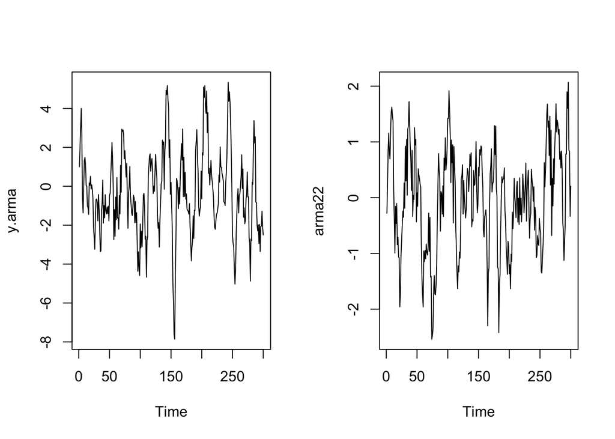

```r
par(mfrow = c(1, 2))
ts.plot(y.arma)
ts.plot(arma22)
```

Berdasarkan plot time series tersebut, terlihat bahwa model ARMA(2,2) cenderung stasioner dalam rataan

#Plot PACF

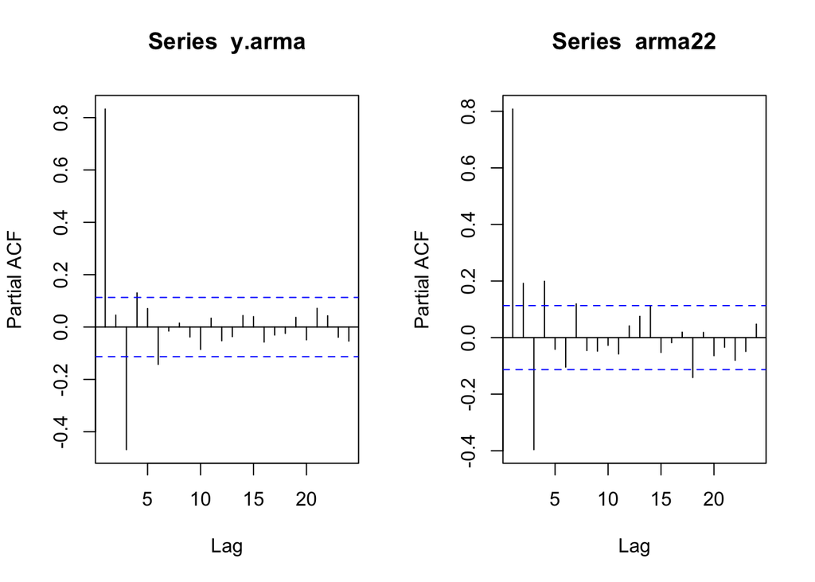

```r
par(mfrow = c(1, 2))
pacf(y.arma)
pacf(arma22)
```

#Plot EACF

```r
TSA::eacf(y.arma)
```

```
## AR/MA
##   0 1 2 3 4 5 6 7 8 9 10 11 12 13
## 0 x x x x x o o o o x x  x  x  x
## 1 o x o x o o o o o o o  o  o  o
## 2 o x x x o x o o o o o  o  o  o
## 3 x x x o o o o o o o o  o  o  o
## 4 x x x o o o o o o o o  o  o  o
## 5 x x x o o o o o o o o  o  o  o
## 6 x x x o o o o o o o o  o  o  o
## 7 x o o x o o x o o o o  o  o  o
```

```r
TSA::eacf(arma22)
```

```
## AR/MA
##   0 1 2 3 4 5 6 7 8 9 10 11 12 13
## 0 x x x x x x x o o o o  o  o  o
## 1 x x x x x o o o o o o  o  o  o
## 2 x x o o o o o o o o o  o  o  o
## 3 x x x o o o o o o o o  o  o  o
## 4 x x x o o o o o o o o  o  o  o
## 5 x x o o o o o o o o o  o  o  o
## 6 x x x o o o o o o o o  o  o  o
## 7 x x o o x o o o o o o  o  o  o
```

#Scatterplot Antar Lag

```r
#Yt
yt_arma1 <- arma22[-1]
yt_arma1
```

```
##   [1]  0.209318137  0.844606129  1.157846752  0.821120441  0.693698896
##   [6]  1.179045236  1.531583885  1.622619113  1.473747568  1.366880594
##  [11]  0.154562227 -0.351863459 -0.994075888 -0.155027824 -0.466221139
##  [16] -0.104978498 -0.844768563 -0.711056398 -1.067237646 -1.077022809
##  [21] -1.958235160 -1.721452544 -1.026399966 -0.762262840 -0.475018060
##  [26] -0.241289663 -0.351792044  0.263450949 -0.191436116  0.923512827
##  [31]  0.301311767  1.045011592  0.044136070  1.230176532  1.288829295
##  [36]  1.721743801  1.313390239  0.921827150  0.656674320  0.128653830
##  [41]  0.849198878 -0.338421514  0.040008865 -0.031691793  1.256517031
##  [46]  0.946717484  1.043071275 -0.434407617  0.086439527 -0.153380870
##  [51]  0.516555637  0.409373842  0.342960027  0.245362109  0.189476461
##  [56] -0.885057397 -1.423113452 -1.760208473 -1.960741347 -0.957771888
##  [61] -1.148782617 -0.945770216 -1.096552847 -0.831620686 -0.974950106
##  [66] -1.029414777 -0.911235612 -0.277301631 -0.965112018 -0.353565803
##  [71] -1.426173667 -1.408920951 -2.538832332 -2.474185905 -2.356209306
```

[output cut: 45 more lines]

```r
#Yt-1
yt_1_arma <- arma22[-200]
yt_1_arma
```

```
##   [1] -0.279179095  0.209318137  0.844606129  1.157846752  0.821120441
##   [6]  0.693698896  1.179045236  1.531583885  1.622619113  1.473747568
##  [11]  1.366880594  0.154562227 -0.351863459 -0.994075888 -0.155027824
##  [16] -0.466221139 -0.104978498 -0.844768563 -0.711056398 -1.067237646
##  [21] -1.077022809 -1.958235160 -1.721452544 -1.026399966 -0.762262840
##  [26] -0.475018060 -0.241289663 -0.351792044  0.263450949 -0.191436116
##  [31]  0.923512827  0.301311767  1.045011592  0.044136070  1.230176532
##  [36]  1.288829295  1.721743801  1.313390239  0.921827150  0.656674320
##  [41]  0.128653830  0.849198878 -0.338421514  0.040008865 -0.031691793
##  [46]  1.256517031  0.946717484  1.043071275 -0.434407617  0.086439527
##  [51] -0.153380870  0.516555637  0.409373842  0.342960027  0.245362109
##  [56]  0.189476461 -0.885057397 -1.423113452 -1.760208473 -1.960741347
##  [61] -0.957771888 -1.148782617 -0.945770216 -1.096552847 -0.831620686
##  [66] -0.974950106 -1.029414777 -0.911235612 -0.277301631 -0.965112018
##  [71] -0.353565803 -1.426173667 -1.408920951 -2.538832332 -2.474185905
```

[output cut: 45 more lines]

```r
#Yt
yt_arma2 <- arma22[-c(1,2)]
yt_arma2
```

```
##   [1]  0.844606129  1.157846752  0.821120441  0.693698896  1.179045236
##   [6]  1.531583885  1.622619113  1.473747568  1.366880594  0.154562227
##  [11] -0.351863459 -0.994075888 -0.155027824 -0.466221139 -0.104978498
##  [16] -0.844768563 -0.711056398 -1.067237646 -1.077022809 -1.958235160
##  [21] -1.721452544 -1.026399966 -0.762262840 -0.475018060 -0.241289663
##  [26] -0.351792044  0.263450949 -0.191436116  0.923512827  0.301311767
##  [31]  1.045011592  0.044136070  1.230176532  1.288829295  1.721743801
##  [36]  1.313390239  0.921827150  0.656674320  0.128653830  0.849198878
##  [41] -0.338421514  0.040008865 -0.031691793  1.256517031  0.946717484
##  [46]  1.043071275 -0.434407617  0.086439527 -0.153380870  0.516555637
##  [51]  0.409373842  0.342960027  0.245362109  0.189476461 -0.885057397
##  [56] -1.423113452 -1.760208473 -1.960741347 -0.957771888 -1.148782617
##  [61] -0.945770216 -1.096552847 -0.831620686 -0.974950106 -1.029414777
##  [66] -0.911235612 -0.277301631 -0.965112018 -0.353565803 -1.426173667
##  [71] -1.408920951 -2.538832332 -2.474185905 -2.356209306 -1.661889365
```

[output cut: 45 more lines]

```r
#Yt-1
yt_2_arma <- arma22[-c(299,300)]
yt_2_arma
```

```
##   [1] -0.279179095  0.209318137  0.844606129  1.157846752  0.821120441
##   [6]  0.693698896  1.179045236  1.531583885  1.622619113  1.473747568
##  [11]  1.366880594  0.154562227 -0.351863459 -0.994075888 -0.155027824
##  [16] -0.466221139 -0.104978498 -0.844768563 -0.711056398 -1.067237646
##  [21] -1.077022809 -1.958235160 -1.721452544 -1.026399966 -0.762262840
##  [26] -0.475018060 -0.241289663 -0.351792044  0.263450949 -0.191436116
##  [31]  0.923512827  0.301311767  1.045011592  0.044136070  1.230176532
##  [36]  1.288829295  1.721743801  1.313390239  0.921827150  0.656674320
##  [41]  0.128653830  0.849198878 -0.338421514  0.040008865 -0.031691793
##  [46]  1.256517031  0.946717484  1.043071275 -0.434407617  0.086439527
##  [51] -0.153380870  0.516555637  0.409373842  0.342960027  0.245362109
##  [56]  0.189476461 -0.885057397 -1.423113452 -1.760208473 -1.960741347
##  [61] -0.957771888 -1.148782617 -0.945770216 -1.096552847 -0.831620686
##  [66] -0.974950106 -1.029414777 -0.911235612 -0.277301631 -0.965112018
##  [71] -0.353565803 -1.426173667 -1.408920951 -2.538832332 -2.474185905
```

[output cut: 45 more lines]

```r
#Yt
yt_arma3 <- arma22[-c(1,2,3)]
yt_arma3
```

```
##   [1]  1.157846752  0.821120441  0.693698896  1.179045236  1.531583885
##   [6]  1.622619113  1.473747568  1.366880594  0.154562227 -0.351863459
##  [11] -0.994075888 -0.155027824 -0.466221139 -0.104978498 -0.844768563
##  [16] -0.711056398 -1.067237646 -1.077022809 -1.958235160 -1.721452544
##  [21] -1.026399966 -0.762262840 -0.475018060 -0.241289663 -0.351792044
##  [26]  0.263450949 -0.191436116  0.923512827  0.301311767  1.045011592
##  [31]  0.044136070  1.230176532  1.288829295  1.721743801  1.313390239
##  [36]  0.921827150  0.656674320  0.128653830  0.849198878 -0.338421514
##  [41]  0.040008865 -0.031691793  1.256517031  0.946717484  1.043071275
##  [46] -0.434407617  0.086439527 -0.153380870  0.516555637  0.409373842
##  [51]  0.342960027  0.245362109  0.189476461 -0.885057397 -1.423113452
##  [56] -1.760208473 -1.960741347 -0.957771888 -1.148782617 -0.945770216
##  [61] -1.096552847 -0.831620686 -0.974950106 -1.029414777 -0.911235612
##  [66] -0.277301631 -0.965112018 -0.353565803 -1.426173667 -1.408920951
##  [71] -2.538832332 -2.474185905 -2.356209306 -1.661889365 -1.397874844
```

[output cut: 45 more lines]

```r
#Yt-1
yt_3_arma <- arma22[-c(298,299,300)]
yt_3_arma
```

```
##   [1] -0.279179095  0.209318137  0.844606129  1.157846752  0.821120441
##   [6]  0.693698896  1.179045236  1.531583885  1.622619113  1.473747568
##  [11]  1.366880594  0.154562227 -0.351863459 -0.994075888 -0.155027824
##  [16] -0.466221139 -0.104978498 -0.844768563 -0.711056398 -1.067237646
##  [21] -1.077022809 -1.958235160 -1.721452544 -1.026399966 -0.762262840
##  [26] -0.475018060 -0.241289663 -0.351792044  0.263450949 -0.191436116
##  [31]  0.923512827  0.301311767  1.045011592  0.044136070  1.230176532
##  [36]  1.288829295  1.721743801  1.313390239  0.921827150  0.656674320
##  [41]  0.128653830  0.849198878 -0.338421514  0.040008865 -0.031691793
##  [46]  1.256517031  0.946717484  1.043071275 -0.434407617  0.086439527
##  [51] -0.153380870  0.516555637  0.409373842  0.342960027  0.245362109
##  [56]  0.189476461 -0.885057397 -1.423113452 -1.760208473 -1.960741347
##  [61] -0.957771888 -1.148782617 -0.945770216 -1.096552847 -0.831620686
##  [66] -0.974950106 -1.029414777 -0.911235612 -0.277301631 -0.965112018
##  [71] -0.353565803 -1.426173667 -1.408920951 -2.538832332 -2.474185905
```

[output cut: 45 more lines]

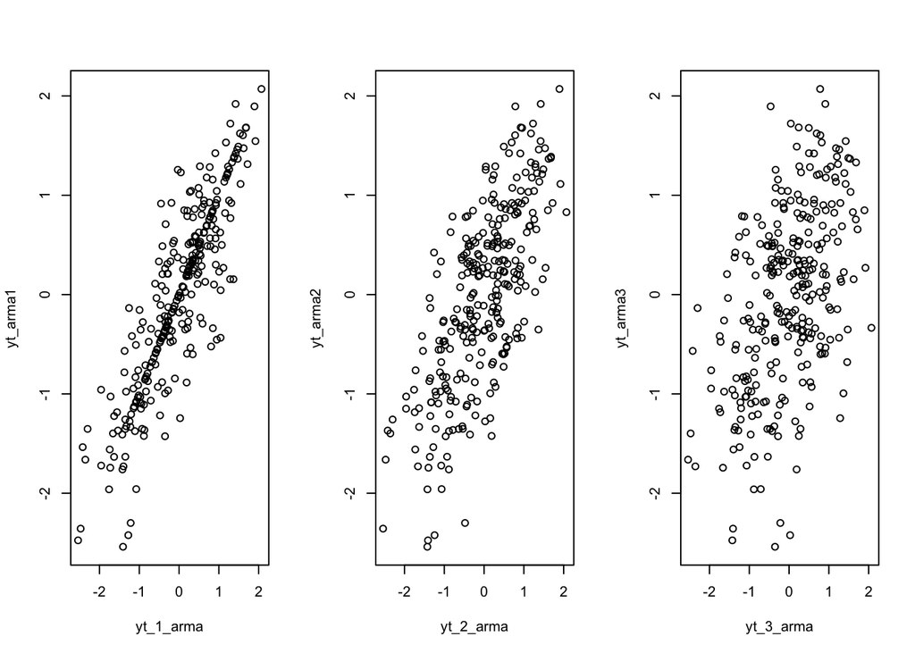

```r
par(mfrow = c(1, 3))
plot(y=yt_arma1,x=yt_1_arma)
plot(y=yt_arma2,x=yt_2_arma)
plot(y=yt_arma3,x=yt_3_arma)
```

```r
cor(yt_arma1,yt_1_arma)
```

```
## [1] 0.8727744
```

```r
cor(yt_arma2,yt_2_arma)
```

```
## [1] 0.7197416
```

```r
cor(yt_arma3,yt_3_arma)
```

```
## [1] 0.4939172
```